# PAC2 - Visualització de dades

Ignasi Elgström

2025-04-03

## Cartogram

Per aquesta primera tècnica, es treballa la tècnica del Cartograma, que consisteix en representar un mapa on cada subdivisió d’aquest es veu augmentat o disminuit segons una propietat comú.

En aquest cas, s’agafa el mapa d’Espanya i es crea un Cartogram segons la població de cada Regió de Comunitat Autònoma. Les dades venen de la llibreria ‘mapSpain’ de R.

[figure not shown]

```r
# Obtemim les dades geografiques i les transformem segons la projecció de Mercator
prov <- esp_get_prov() %>%
  mutate(name = prov.shortname.es) %>%
  select(name, cpro)
prov_3857 <- st_transform(prov, 3857)

#Obtenim la població per provincia
pop_provinces <- pobmun19 %>%
  group_by(cpro) %>%
  summarise(n_pop = sum(pob19))

#Adjuntem les dades
prov_3857_data <- prov_3857 %>%
  left_join(pop_provinces, by = c("cpro"))

#Fem el plot
prov_3857_data_cartog_cont <- cartogram_cont(prov_3857_data, weight = "n_pop")
ggplot(prov_3857_data_cartog_cont) +  geom_sf(aes(fill = n_pop))+
  labs(title = "Cartograma de la població per Regió de CCAA a Espanya",
       x = "Longitud",
       y = "Latitud")
```

## Arc diagram

Aquest plot tracta sobre les relacions entre multiples elements d’un graf, de forma horitzontal i mostrant alhora les conexions en cadascun dels nodes.

En el següent graf es mostra cadascún dels personatges de la novela ‘Les Miserable’ i cada conexió entre dos nodes/personatge implica que aquest coparteixen un capítol d’un llibre.

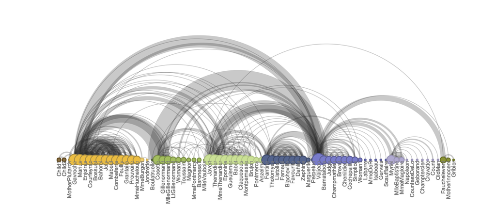

```r
# Carreguem l'arxiu a analitzar
mis_file = "lesmiserables.gml"
mis_graph = read_graph(mis_file, format="gml")

#Obtenim els atributs del graf.
edgelist = as_edgelist(mis_graph)
vlabels = vertex_attr(mis_graph, "label")
vgroups = vertex_attr(mis_graph, "group")
vfill = vertex_attr(mis_graph, "fill")
vborders = vertex_attr(mis_graph, "border")
degrees = degree(mis_graph)
values = edge_attr(mis_graph, "value")

#Agrupem les dades i les ordenem per grups i distàncies
x = data.frame(vgroups, degrees, vlabels, ind=1:vcount(mis_graph))
y = arrange(x, desc(vgroups), desc(degrees))
new_ord = y$ind

#Fem el plot
arcplot(edgelist, ordering=new_ord, labels=vlabels, cex.labels=0.8,
        show.nodes=TRUE, col.nodes=vborders, bg.nodes=vfill,
        cex.nodes = log(degrees)+0.5, pch.nodes=21,
        lwd.nodes = 2, line=-0.5,
        col.arcs = hsv(0, 0, 0.2, 0.25), lwd.arcs = 1.5 * values)
```

## Connected Scatterplot

Aquest plot es basa en il·lustrar l’evolució d’una variable X amb segments entre els punts alhora que marcant cada punt. Aquest graf mostra mes clarament els detalls de l’evolució de punts alhora que marca la tendència entre aquests.

En aquest gràfic mostrem una evolució del conjunt de dades ‘economics’, on s’hi representa el valor de l’atur a EEUU entre el 1995 i el 2000.

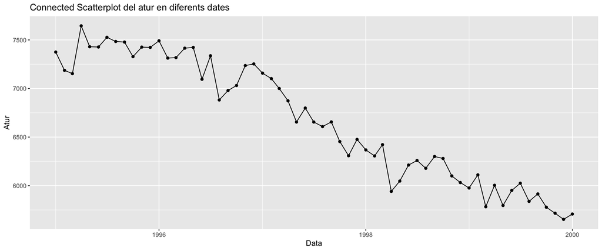

```r
start_date <- as.Date("1995-01-01")
end_date <- as.Date("2000-01-01")

# Filtrem les dades per data
filtered_data <- economics %>%
  filter(date >= start_date & date <= end_date)

# Fem el plot
ggplot(filtered_data, aes(x = date, y = unemploy)) +
  geom_point() +
  geom_line() +
  scale_x_date() +  # Escala automatica
  labs(title = "Connected Scatterplot del atur en diferents dates",
       x = "Data",
       y = "Atur")
```